# DAMEfinder Workflow

Stephany Orjuela, Dania Machlab and Mark Robinson

sorjuelal@gmail.com  
dania.machlab@gmail.com  
mark.robinson@imls.uzh.ch

2018-09-06

#### Package

DAMEfinder 0.1.13

# 1 DAMEfinder Overview

DAMEfinder runs in two modes: **SNP-based** (exhaustive-mode) and **tuple-based** (fast-mode), which come together when differential methylation is identified:

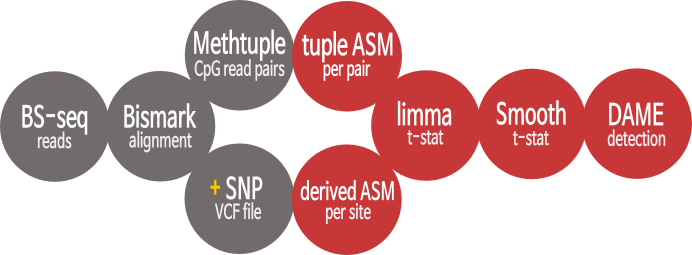

## 1.1 Get bam files

In order to run any of the two modes, you must obtain aligned `bam` files using [`bismark`](http://www.bioinformatics.babraham.ac.uk/projects/bismark/). Here we demonstrate how to generate these starting from paired-end `fastq` files of bisulfite-treated reads:

```bash
#Check quality of reads
fastqc -t 2  sample1_R1.fastq.gz sample1_R2.fastq.gz

#Trim reads to remove bad quality regions and adapter sequence
trim_galore --paired sample1_R1.fastq.gz sample2_R2.fastq.gz
```

To trim the reads we use [`Trim Galore`](https://github.com/FelixKrueger/TrimGalore) and specify the use of paired reads. By default it will remove any adapter sequence it recognizes. Please refer to the [user guide](https://github.com/FelixKrueger/TrimGalore/blob/master/Docs/Trim_Galore_User_Guide.md) for further specifications.

```bash
#Build bisulfite reference
bismark_genome_preparation <path_to_genome_folder>

#run Bismark
bismark -B sample1 --genome <path_to_genome_folder> -1 sample1_R1_val_1.fq.gz -2 sample1_R2_val_2.fq.gz

#deduplicate (optional)
deduplicate_bismark -p --bam sample1_pe.bam

#sort and index files
samtools sort -m 20G -O bam -T _tmp -o sample1_pe.dedupl_s.bam sample1_pe.deduplicated.bam
samtools index file1_pe.dedupl_s.bam
```

Before the alignment, you must download a reference fasta file from [Ensembl](https://www.ensembl.org/info/data/ftp/index.html) or [Gencode](https://www.gencodegenes.org/), and generate a bisulfite converted reference. For this we use `bismark_genome_preparation` from the `bismark` suite, and specify the folder that contains the `fasta` file with its index file. Depending on the library type and kit used to obtains the reads, you may want to deduplicate your bam files (e.g. TruSeq). Please refer to the [user guide](https://rawgit.com/FelixKrueger/Bismark/master/Docs/Bismark_User_Guide.html) for further explanation and specifications.

# 2 SNP-based (aka slow-mode)

## 2.1 Example Workflow

In this example we use a dataset from (cite serrated paper). We include samples from two patients with colo-rectal cancer. For each patient two samples were taken: `NORM#` corresponds to normal mucosa tissue and `CRC#` corresponds to the paired adenoma lesion. Each of these samples was sequenced using targeted BS-seq followed by variant calling using `Bis-SNP`.

### 2.1.1 Obtain allele-based methylation calls

Similar to the `bismark_methylation_extractor`, we obtain methylation calls. However since we are interested in allele-specific methylation, we only extract methylation for CpG sites that fall within reads including a SNP. For every SNP in the `VCF` file an independent methylation call is performed by using `split_bams`, which “splits” reads from the `BAM` file according to the alleles:

```r
library(DAMEfinder)

bam_files <- c(system.file("extdata", "NORM1_chr19.bam", package = "DAMEfinder"),
               system.file("extdata", "CRC1_chr19.bam", package = "DAMEfinder"))

vcf_files <- c(system.file("extdata", "NORM1.chr19.moretrim.vcf", package = "DAMEfinder"),
               system.file("extdata", "CRC1.chr19.moretrim.vcf", package = "DAMEfinder"))

sample_names <- c("NORM1", "CRC1")

reference_file <- system.file("extdata", "19.fa", package = "DAMEfinder")

#Split reads and extract methylation according to allele
split_bams(bam_files, vcf_files, sample_names, reference_file)
```

```
## Reading reference file
```

```
## Running sample NORM1
```

```
## Reading VCF file
```

```
## Extracting methylation per SNP
```

```
## 0 or 1 read in one or both alleles
## 0 or 1 read in one or both alleles
## 0 or 1 read in one or both alleles
## 0 or 1 read in one or both alleles
```

```
## Saving results for sample NORM1
```

```
## Running sample CRC1
```

```
## Reading VCF file
```

```
## Extracting methylation per SNP
```

```
## 0 or 1 read in one or both alleles
```

```
## Saving results for sample CRC1
```

```r
#Read in one of the generated files
snp.table <- readRDS("snp.table.NORM1.rds")

#CpG sites for first SNP in VCF file
snp.table[[1]]
```

```
## GRanges object with 25 ranges and 5 metadata columns:
##        seqnames    ranges strand |   cov.ref   cov.alt  meth.ref  meth.alt
##           <Rle> <IRanges>  <Rle> | <numeric> <numeric> <numeric> <numeric>
##    [1]       19    266932      * |         1         1         0         0
##    [2]       19    266963      * |         3         2         0         0
##    [3]       19    266999      * |         8        11         0         0
##    [4]       19    267087      * |        33        33         0         1
##    [5]       19    267097      * |        32        33         1         3
##    ...      ...       ...    ... .       ...       ...       ...       ...
##   [21]       19    267207      * |         4         2         0         0
##   [22]       19    267215      * |         3         1         0         0
##   [23]       19    267224      * |         3         1         0         0
##   [24]       19    267229      * |         2         1         0         0
##   [25]       19    267234      * |         2         1         0         0
##                snp
##        <character>
##    [1]   19.267039
##    [2]   19.267039
##    [3]   19.267039
##    [4]   19.267039
##    [5]   19.267039
##    ...         ...
##   [21]   19.267039
##   [22]   19.267039
##   [23]   19.267039
##   [24]   19.267039
##   [25]   19.267039
##   -------
##   seqinfo: 1 sequence from an unspecified genome; no seqlengths
```

```r
#CpG sites for second SNP in VCF file
snp.table[[2]]
```

```
## GRanges object with 10 ranges and 5 metadata columns:
##        seqnames    ranges strand |   cov.ref   cov.alt  meth.ref  meth.alt
##           <Rle> <IRanges>  <Rle> | <numeric> <numeric> <numeric> <numeric>
##    [1]       19    281248      * |        26        18        24        16
##    [2]       19    281255      * |        28        22        28        22
##    [3]       19    281292      * |        40        34        31        27
##    [4]       19    281377      * |        44        57        35        47
##    [5]       19    281384      * |        39        51        30        46
##    [6]       19    281404      * |        33        42        28        37
##    [7]       19    281433      * |        23        37        20        29
##    [8]       19    281446      * |        22        33        10        15
##    [9]       19    281468      * |        15        18         9        12
##   [10]       19    281507      * |         5         3         2         2
##                snp
##        <character>
##    [1]   19.281360
##    [2]   19.281360
##    [3]   19.281360
##    [4]   19.281360
##    [5]   19.281360
##    [6]   19.281360
##    [7]   19.281360
##    [8]   19.281360
##    [9]   19.281360
##   [10]   19.281360
##   -------
##   seqinfo: 1 sequence from an unspecified genome; no seqlengths
```

```r
#And so on...
```

For demonstration, we include `BAM` files from chromosome 19, and `VCF` files with 43 SNPs. Typically we would run the function on an entire `BAM` and `VCF` file, which would generate a large output and occupy a lot of memory. Because of this we save the output in an `.rds` file for each sample as `snp.table.<sample_name>.rds`.

The function also takes as input the reference file used to generate the alignments. For demonstration we use chromosome 19 of the `GRCh37.91` reference fasta file.

### 2.1.2 Summarize methylation calls across samples

Typically you won’t have to deal with the `.rds` files, because we have a function that reads in all the files generated by `split_bams()` and summarizes all the necesarry information into a `SummarizedExperiment` object:

```r
rds_files <- list("snp.table.NORM1.rds", "snp.table.CRC1.rds")
derASM <- calc_derivedasm(rds_files)
```

```
## ..Summarizing scores
## Summarizing coverages
## Summarizing SNP info
## Returning 131 CpG sites for 2 samples
```

```r
derASM
```

```
## class: RangedSummarizedExperiment
## dim: 131 2
## metadata(0):
## assays(6): der.ASM snp.table ... ref.meth alt.meth
## rownames(131): 19.267097 19.267109 ... 19.526566 19.526585
## rowData names(0):
## colnames(2): NORM1 CRC1
## colData names(1): samples
```

Every row in the object is a single CpG site, and each column a sample. It contains 6 matrices in `assays`:

- der.ASM: Derived SNP-based ASM: $abs(\frac{X^{r}_M}{X^{r}} - \frac{X^{a}_M}{X^{a}})$
- snp.table: Location of the SNP associated to the CpG site
- ref.cov: Coverage of the “reference” allele
- alt.cov: Coevarage of the “alternative” allele
- ref.meth: Methylated reads from the “reference” allele
- alt.meth: Methylated reads from the “alternative” allele

You can access these assays as:

```r
suppressPackageStartupMessages(library(SummarizedExperiment))

head(assays(derASM)[["der.ASM"]])
```

```
##                NORM1       CRC1
## 19.267097 0.05965909 0.02083333
## 19.267109 0.06250000 0.00951087
## 19.267117 0.03225806 0.01003584
## 19.267139 0.03571429 0.02500000
## 19.267155 0.04347826 0.03225806
## 19.281248 0.03418803 0.03846154
```

Next, we obtain a moderated t-statistic per CpG site using `limma`. The statistic reflects a measure of difference between the two conditions being compared, in this case normal Vs cancer. The t-Statistic is smoothed using `bumphunter`.

For each condition being compared, we recommend at least three biological replicates. This ensures enough biological variability to calculate residual degrees of freedom in the linear model fit.

```r
# Make a design matrix that specifies the two conditions per sample
cols <- rep(1,ncol(derASM))
n <- grep("NORM", colnames(derASM))
cols[n] <- 0

mod <- matrix(data=c(rep(1,ncol(derASM)), cols), ncol = 2)
mod

# Get t-Statistics
tStatistics <- get_tstats(derASM, mod, method = "ls")
```

[output not shown]

### 2.1.4 Find DAMEs

Finally, we detect regions that show differential ASM. We provide a wraper of the `regionFinder()` function from `bumphunter`, and specify a cutoff as the Qth quantile of the absolute values of the given smoothed t-Statistics.

```r
dames <- find_dames(tStatistics, Q=0.9, maxGap=20)

head(dames)
```

[output not shown]

# 3 tuple-based (aka fast-mode)

Before running the tuple-based mode, you must obtain files from the `methtuple` tool to input them in the `read_tuples` function.

## 3.1 Run Methtuple on bam files

Methtuple requires the input `BAM` files of paired-end reads to be sorted by query name. For more information on the options in `methtuple`, refer to the user [guide](https://github.com/PeteHaitch/methtuple). For example the `--sc` option combines strand information.

```bash
# Sort bam file by query name
samtools sort -n -@ 10 -m 20G -O bam -T _tmp -o sample1_pe_sorted.bam sample1_pe.deduplicated.bam

# Run methtuple
methtuple --sc --gzip -m 2 sample1_pe_sorted.bam
```

## 3.2 Example Workflow

### 3.2.1 Read methtuple files

We use the same samples as above to run `methtuple` and obtain `.tsv.gz` files. We read in these files using `read_tuples` and obtain a list of `tibble`s, each one for every sample:

```r
tuple_files <- c(system.file("extdata", "NORM1_chr19_qs.CG.2.tsv.gz", package = "DAMEfinder"),
                 system.file("extdata", "CRC1_chr19_qs.CG.2.tsv.gz", package = "DAMEfinder"))


tuple_list <- read_tuples(files = tuple_files, sample_names)
```

```
## Reading /home/stephany/R/x86_64-pc-linux-gnu-library/3.5/DAMEfinder/extdata/NORM1_chr19_qs.CG.2.tsv.gz
```

```
## Reading /home/stephany/R/x86_64-pc-linux-gnu-library/3.5/DAMEfinder/extdata/CRC1_chr19_qs.CG.2.tsv.gz
```

```
## Filtering and sorting: .. done.
```

```r
head(tuple_list$NORM1)
```

```
## # A tibble: 6 x 10
##   chr   strand  pos1  pos2    MM    MU    UM    UU   cov inter_dist
##   <chr> <chr>  <int> <int> <int> <int> <int> <int> <int>      <int>
## 1 19    *      70996 70999     0     0     0     2     2          3
## 2 19    *      70999 71010     0     0     0     2     2         11
## 3 19    *      71010 71014     0     0     0     3     3          4
## 4 19    *      71014 71016     0     0     0     3     3          2
## 5 19    *      71016 71022     0     0     0     3     3          6
## 6 19    *      71022 71032     0     0     0     3     3         10
```

Each row in the `tibble` displays a tuple. The chromosome name and strand are shown followed by `pos1` and `pos2` which refer to the genomic positions of the first and second CpG in the tuple. The `MM`, `MU`, `UM`, and `UU` counts of the tuple are displayed where `M` stands for methylated and `U` for unmethylated. For example, `UM` shows the read counts for the instances where `pos1` is unmethylated and `pos2` is methylated. The coverage and distance between the two genomic positions in the tuple are shown under `cov` and `inter_dist` respectively.

### 3.2.2 Calculate ASM Score

The calc_asm function takes in the output from `read_tuples()` and outputs a `SummarizedExperiment` where each row is a tuple and each column is a sample. As in the SNP-based mode, the object contains 6 assays including the `MM`, `MU`, `UM`, and `UU` counts, as well as the total coverage and the tuple-based ASM score.

This score is a measure ASM calculated directly from the reads without the need of SNP information. Because of this it is a lot quicker than the SNP-based ASM, and is useful for more explorative questions. Equations (1), (2) and (3) show how the score is calculated. The log odds ratio in equation (1) provides a higher score the more `MM` and `UU` counts the tuple has, whereas a higher `UM` and `MU` would indicate “random” methylation. The weight further adds allele-specificity where a rather balanced MM:UU count provides the tuple with a higher score.

$$\begin{equation}
ASM^{(i)} = log{ \Big\{ \frac{X_{MM}^{(i)} \cdot X_{UU}^{(i)}}{X_{MU}^{(i)} \cdot X_{UM}^{(i)}} \Big\} \cdot w_i }
\tag{1}
\end{equation}$$

$$\begin{equation}
w_i = P(0.5-\epsilon < \theta < 0.5+\epsilon~|~ X_{MM}^{(i)}, X_{UU}^{(i)}, \beta_1, \beta_2)
\tag{2}
\end{equation}$$

$$\begin{equation}
\theta^{(i)} | X_{MM}^{(i)}, X_{UU}^{(i)},\beta_1, \beta_2 \sim Beta(\beta_1+X_{MM}^{(i)}, \beta_2+X_{UU}^{(i)})
\tag{3}
\end{equation}$$

where $\theta^{(i)}$ represents the moderated proportion of MM to MM+UU alleles. The weight, $w_i$ is set such that the observed split between MM and UU alleles can depart somewhat from 50/50, while fully methylated or unmethylated tuples, which represents evidence for absence of allele-specificity, are attenuated to 0. The degree of allowed departure can be set according to $\epsilon$, the deviation from 50/50 allowed and the level of moderation, $\beta_1$ and $\beta_2$.

```r
ASM_mat <- calc_asm(sample_list = tuple_list)
```

```
## Calculating log odds.
```

```
## Calculating ASM score: .. done.
## Creating position pair keys: .. done.
## Assembling table: .. done.
## Transforming.
## Assembling coverage tables: ..........Returning SummarizedExperiment with 281088 CpG pairs
```

```r
ASM_mat
```

```
## class: RangedSummarizedExperiment
## dim: 281088 2
## metadata(0):
## assays(6): asm cov ... UM UU
## rownames(281088): 19.70944.70954 19.70954.70957 ...
##   19.59118758.59118766 19.59118788.59118796
## rowData names(1): midpt
## colnames(2): NORM1 CRC1
## colData names(0):
```

*At this point, the user may want to remove rows (tuples) in the ASM_score_matrix, where all samples of one condition have NA values. One can also set a minimum number of samples to have counts per tuple as a further restriction. However, removing tuples that have NA values in all samples of a particular condition is a necessary step.*

### 3.2.3 Remove tuples without a SNP

1. Get a `VCF` file from your species [dbSNP](https://www.ncbi.nlm.nih.gov/variation/docs/human_variation_vcf/) ftp site [ensembl](http://www.ensembl.org/info/data/ftp/index.html) ftp site
2. Load that file into R with `vcfR`. For more info on this package click [here](https://knausb.github.io/vcfR_documentation/index.html)

```r
#sample_list_no_snps <- parallel::mclapply(sample_list, remove_snps, mc.cores=6)
```

### 3.2.4 Get t-Statistics per tuple and obtain DAMEs

As above, the `SummarizedExperiment` is used to detect differential ASM:

```r
tStatistics <- get_tstats(ASm_mat)

dames <- find_dames(tStatistics, Q=0.9, maxGap=20)

head(dames)
```

[output not shown]

# 4 Visualization

## 4.1 Methyl-circle plot

A typical way of visualizing ASM is to look at the reads overlapping a particular SNP, and the methylation state of the CpG sites in those reads (black circles for methylated and white for unmethylated) (See example [here](https://www.ncbi.nlm.nih.gov/pmc/articles/PMC2892089/)). Here we offer this option with the function `methyl_circle_plot()`. As input it takes a GRanges with the SNP of interest, and the `BAM`, `VCF` and reference files as in the `split_bams()` function.

```r
library(GenomicRanges)
snp <- GRanges(19, IRanges(267039, width = 1))

snp
```

```
## GRanges object with 1 range and 0 metadata columns:
##       seqnames    ranges strand
##          <Rle> <IRanges>  <Rle>
##   [1]       19    267039      *
##   -------
##   seqinfo: 1 sequence from an unspecified genome; no seqlengths
```

```
## Reading vcf file
```

[output not shown]

```
## Getting reads
```

```
## Sorting reads
```

```
## Reading reference
```

```
## Getting meth state per read-pair
```

```
## Plotting
```

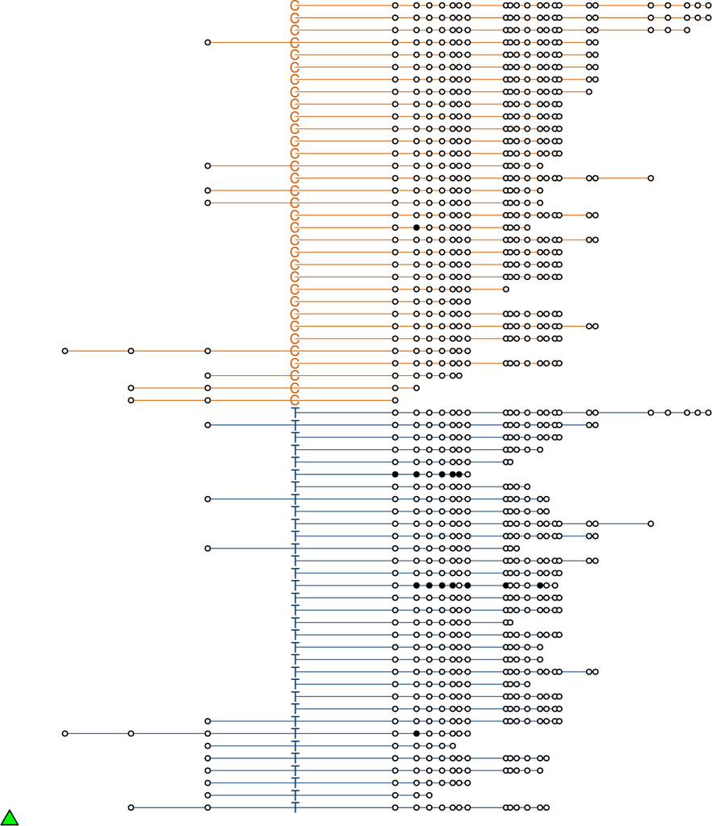

```r
bam.file <- system.file("extdata", "NORM1_chr19.bam", package = "DAMEfinder")

vcf.file <- system.file("extdata", "NORM1.chr19.moretrim.vcf", package = "DAMEfinder")

ref.file <- system.file("extdata", "19.fa", package = "DAMEfinder")

methyl_circle_plot(snp = snp, vcf.file = vcf.file, bam.file = bam.file, ref.file = ref.file, sample.name = "sample1")
```

If you are interested in a specific CpG site within this plot, you can include an extra GRanges with its location:

```
## Reading vcf file
```

```
## Getting reads
```

```
## Sorting reads
```

```
## Reading reference
```

```
## Getting meth state per read-pair
```

```
## Plotting
```

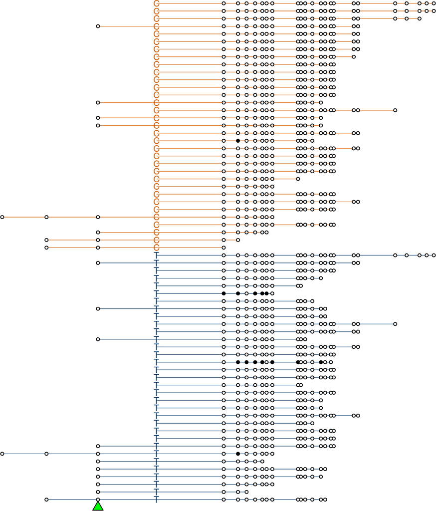

```r
cpgsite <- GRanges(19, IRanges(266998, width = 1))

methyl_circle_plot(snp = snp, vcf.file = vcf.file, bam.file = bam.file, ref.file = ref.file, sample.name = "sample1", cpgsite = cpgsite)
```

If you are instead interested in reads overlapping a CpG site, you can use an alternative function

```
## Reading reference
```

```
## Getting meth state per read-pair
```

```
## Plotting
```

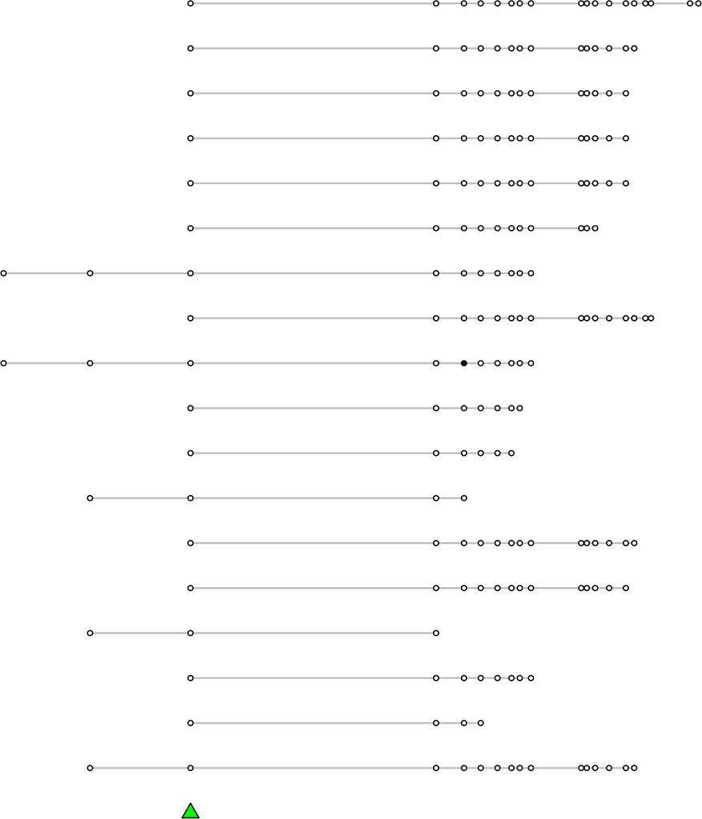

```r
cpgsite <- GRanges(19, IRanges(266998, width = 1))

methyl_circle_plotCpG(cpgsite = cpgsite, bam.file = bam.file, ref.file = ref.file)
```